# R Programming using the Tidyverse

Dr. Peter McKenna

10 October 2018

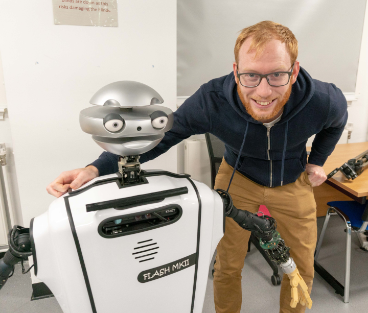

## **Introduction**

- A bit about me… I’m a postdoc studying human-robot interaction. Use expertise of experimental design to help roboticists effectively evaluate their systems. Currently designing a social skills training robot for adults with an autism-spectrum condition.
- In this introductory class you are going to learn how to: >- read a .csv file into R Studio >- wrangle and explore the data using Tidyverse methods

## **Considerations**

- Today we are skimming the surface of R’s functionality
- R has a steep learning curve relative to other high level stats packages (e.g. SPSS)
- You are going to make mistakes - a single letter out of place will cause errors. Take your time!
- Persistence is greatly rewarded in the long-term

## **Tidyverse**

- Today we are using *Tidyverse* methods to wrangle and analyse the data
- The Tidyverse is a set of R packages that allows for more user friendly programming, relative to what’s called *base R*
- For more about the Tidyverse see Hadley Wickham’s free online text [R for Data Science](http://r4ds.had.co.nz/)
- Our first task is to install these packages and load them to R Studio

## **Tidyverse packages**

- `readr` - for reading in data
- `tidyr` - for tidying & wrangling data
- `dplyr` - for tidying & wrangling data
- `ggplot2`- for plotting data

## **Main verbs of R’s Tidyverse**

- These packages allow us to use Tidyverse verbs:
- `filter`: extract rows
- `select`: extract columns
- `gather/spread`: gather columns into rows/spread rows into columns
- `mutate`: compute and append new/existing columns
- `summarise`: summarise data based on stated criteria

## **Relatedly…Pipes!**

- You are going to see a lot of this symbol `%>%`
- This is the *pipe* operator
- Do not fear the pipe operator
- It means is “then do this”

## Setting up a working directory using projects

- *Projects* in R create unique directories for your studies
- Simply open R Studio, go to `File` -> `New Project` -> `New Directory` -> and choose the directory you selected for the data
- Then retrieve the data from https://github.com/petermckenna/psych-r-demo
- on this page click **Clone or download** –> **Download ZIP**
- Save the Zip folder in your R project directory
- You may need to copy it from your *Downloads* folder

## **Start your own script**

- You are now ready to start your own script
- Scripts are edited in the *Workspace Tab* - above the R Console
- Create script headings using `#` (called a “comment”; inactive code)
- Now your directory is set up the first task is to install and load the necessary packages

## **Installing Packages**

```r
install.packages('readr')   # installs the 'readr' package
install.packages('tidyr')   # installs the 'tidyr' package
install.packages('dplyr')   # installs the 'dplyr' package

# Note: if you were here at the last demo these packages should already be installed
# If you're unsure run the code again
```

- To execute code press `Ctrl + Enter`
- This can be done for single lines, or multiple lines by highlighting sections
- Package installation take a minute

## **Loading in the packages**

```r
library(readr)   # load 'readr' package
library(tidyr)   # load 'tidyr' package
library(dplyr)   # load 'dplyr' package

# if you're confident you have already installed the packages all you need to do is load them
```

- do not be concerned by the text generated in the console; R packages are stamped to certain versions of R Studio, but work fine once loaded

## **Reading in the data**

- We then read in the data (a .csv file) using the following code

`tibble <- read_csv("name_of_the_file.csv")`

- this syntax creates a data table (or **tibble**) called from an existing .csv data file using the assign function `<-`
- most often the tibble is assigned the name `data` or `df` (for data frame)
- my advice: keep it simple

## **Viewing the data**

- Let’s have a look at the data
- Do do this you can click on your tibble created in the *Global Environment* (panel in top right)
- There are several commands we can use to perform a sanity check before we get going
- `View(data)`: note the capital V, this opens a new window showing the tibble in its entirety
- `head(data)`: shows first 6 rows
- `tail(data)`: shows bottom 6 rows
- `str(data)`: structure of the tibble; e.g. the type of data contained in each vector

## **Description of the data**

- The data details 60 children’s fixation duration on a robot’s face during a collaborative game
- There are three different age groups: 5-6, 7-8, and 9-10
- The data is in the *wide format* where each vector (or column) represents a unique condition
- This format is preferable for analysis in Excel and SPSS, but NOT for R where we want data to be in the *long format*

## Wrangling and shaping the data

- There will often be times where you want to amend or add to your data set
- The *Tidyverse* syntax allows you to do this with a set of simple commands
- The following examples give you the opportunity to see how the main verbs of the Tidyverse work

## Using gather

- `gather` is an important tool for converting data from the *wide format* into the *long format*
- the syntax is split into the following parts

`gather(data, key = "key", value = "value")`

- So, when using the gather function we need to
- `data` = specify the data
- `key` = give our grouping vector a label
- `value` = and label the observations (e.g. the dependent variable)

## Crucial point - specfying data

- if you are piping (e.g. `%>%`) your data into the `gather` command then gather ALREADY KNOWS WHAT THE DATA IS
- In other words, you do not need to specify what the `data` is if you have mentioned it at the beginning of the argument
- This applies to all of the commands in the *Tidyverse*, where the preferred method is to specify the data at the beginning and perform operations thereafter

## Exercise 1: Gathering the data

- create a tibble that is the gathered form of the original data
- use the description of the data to give meaningful labels to `key` and `value`

To begin, you code should look something like this

```r
newdata <- data %>%
  "tidyverse_command"
```

- remember `%>%` means “then do this”
- be sure that the number of brackets is matched at the beginning and end of your code
- Once your data has been gathered inspect it again using the `View` command

`View(newdata)`

- what do you notice about the shape of the data?
- What has `gather` done?

## Execerise 2: `mutate` to add an ID colummn

`mutate(.data, new_vector = 1:n())`

- I have given you a head start here with the argument: `1:n()` is a count argument that produces *1 to number of observations per row*
- Remember the rule about piping data

## Other useful ways to use `mutate`

- Now you’re getting a little more familiar with Tidyverse syntax
- Have a look at the following bit of code

`mutate_if(is.numeric, round, digits = 2)`

- What do you think the following line of code will do? Discuss with your neighbour if you’re not sure
- Once you’ve figured it out, try adding this line to the end of your pipeline.

## Exercise 3: Using `rename` and `left_join` to add IQ data

- What if we were also interested in children IQ, and if that had an effect on their fixation duration?
- I have created a separate tibble called `iq_data.csv`
- First create a tibble from this data using `read_csv` like we did earlier
- Have a look at your new tibble using `View`
- We are going to combine both of our tibbles using the command `left_join` to create a larger, more detailed tibble
- However, to do so we must have a *SET OF VECTORS WITH THE SAME LABEL IN EACH TIBBLE*
- In `iq_dat.csv` the vector for id is `id`
- If you called your id column `ID` in the fixation time tibble then we need to `rename` that vector before joining
- If they are already the same name just follow along for practice
- Using `rename` is fairly trivial, although a little confusing at first
- Simply pipe your data into the following argument

`rename(new_vector_name = old_vector_name)`

- Notice that the new vector name comes before the old one…weird, but fine once you get your head around it

## Joining our datasets

- OK, now we have a vector in common between the two tibbles
- Let’s being them together to create a master dataset
- To do so, we use `left_join`

```r
newdata <- data %>%
  left_join(x, y, by = "vector_in_common")
```

- `x` and `y` in this instance represent your different tibbles
- `by` want to know the name of the vector in common - remember to use quotations
- Have a look at your new tibble using `View`

## Exercise 4: Filtering the data using `filter`

- What if for some reason you want to exclude a certain group from the data for later analysis?
- This can be achieved easily enough using the `filter` command

```r
newdata <- data %>%
  filter(vector_of_interest = condition_of_filter)
```

- Using `filter, create a new tibble that only includes IQ scores above 90
- Also, try to create a new object that only has children from 5-6 years old

Some hints

- the operator `==` means is equal to
- the operator `!=` means does not equal
- likewise, you can use `<` and `>`

## Exercise 5: Generating overall and group descriptve statistics

- In this final section we are going to produce summaries for our master tibble using the `summarise` command
- There are a number of commands that `summarise` understands, and these can be found in the `Help` tab (bottom-right panel)
- To begin, let’s focus on the `mean` and `sd` for each of our DV (fixation duration, IQ)
- To generate overall descriptives simply pipe the data into the `summarise` command and specify what you would like summarise

```r
new_data <- data %>%
  summarise(avg = mean(DV),
            sd = sd(DV))
```

- You can do this for multiple DVs, simply add another argument to your summarise command

## Group level summaries

- Given that we have three different age groups in the data it is of interest to examine the trends between the groups
- To generate group level summaries we use the `group_by` command
- We use the same approach as before, only we tell R that we’d like to group the data before generating our summaries

```r
new_data <- data %>%
  group_by(grouping_variable) %>%
  summarise(avg = mean(DV),
            sd = sd(DV))
```

## **Resources**

- [R for Data Science](http://r4ds.had.co.nz/) – useful for learning *Tidyverse* syntax
- [The R Book](https://www.cs.upc.edu/~robert/teaching/estadistica/TheRBook.pdf) – useful for data analysis syntax
- [Data Wrangling and Tidying cheatsheet](https://www.rstudio.com/wp-content/uploads/2015/02/data-wrangling-cheatsheet.pdf) – useful for wrangling and tidying syntax of the *Tidyverse*
- [ggplot2 cheatsheet](https://www.rstudio.com/wp-content/uploads/2015/03/ggplot2-cheatsheet.pdf) – useful for learning to plot with ggplot2
- [R Studio cheatsheets](https://www.rstudio.com/resources/cheatsheets/) – useful guides for all things R Studio
- Plotting means and error bars – useful guide for plotting means and error bars with ggplot2